# Soluções da Lista de Exercícios - Treinamento para a Avaliação 2

Introdução à Ciência de Dados  
Bacharelado em administração

Autor

Prof. Dr. Washington S. da Silva

Data de Publicação

13 de junho de 2025

# Tópico: Distribuição Normal — Probabilidades e Quantis

## Exercício 1

1. Qual a probabilidade de um pedido ser entregue em até **7 dias**?

```r
# Parâmetros da distribuição normal
media <- 5
dp <- 2

# 1. P(Entrega <= 7 dias)
prob_ate_7 <- pnorm(7, mean = media, sd = dp)
prob_ate_7
```

```
[1] 0.84134
```

2. Qual a probabilidade de a entrega demorar **mais de 10 dias**?

```r
# 2. P(Entrega > 10 dias)
prob_maior_que_10 <- 1 - pnorm(10, mean = media, sd = dp)
prob_maior_que_10
```

```
[1] 0.0062097
```

3. Qual é o prazo máximo de entrega para que **80%** dos pedidos sejam entregues até essa data?

```r
# 3. Quantil correspondente a 80%
prazo_80 <- qnorm(0.80, mean = media, sd = dp)
prazo_80
```

```
[1] 6.6832
```

4. Forneça uma interpretação para os resultados obtidos em cada item.

**Interpretação dos resultados**

1. Cerca de 84,13% dos pedidos são entregues em até 7 dias.
2. Apenas 0,62% das entregas ultrapassam 10 dias.
3. Para garantir que 80% dos pedidos sejam entregues até o prazo prometido, o limite ideal seria aproximadamente (6,68) $\approx$ **7 dias**.

# Tópico: Valor-em-Risco (VaR) com Distribuição Normal

## Exercício 2

```r
# Parâmetros
retorno_medio <- 0.01
volatilidade <- 0.04
valor_investido <- 50000
```

```r
# Quantil da distribuição normal padrão para 5%
quantil_5 <- qnorm(0.05)  # ≈ -1.645
quantil_5
```

```
[1] -1.6449
```

Cálculo do VaR percentual:

```r
var_percentual <- retorno_medio + quantil_5 * volatilidade
var_percentual
```

```
[1] -0.055794
```

VaR em reais (valor absoluto da perda):

```r
var_monetario <- abs(valor_investido * var_percentual)
var_monetario
```

```
[1] 2789.7
```

**Interpretação do VaR**

Com 95% de confiança, o investidor pode esperar uma perda máxima de aproximadamente **R$ 2.789,70** em um mês. Ou seja, há 5% de probabilidade de uma perda superior a esse valor.

# Tópico: Simulação de Monte Carlo e Valor Esperado

## Exercício 3

## Solução do Exercício 3

1. Calcule o prêmio **justo** (valor esperado).

```r
# Parâmetros
p <- 0.02
indenizacao <- 4000
margem <- 0.20
```

```r
# 1. Prêmio justo (valor esperado)
valor_esperado <- p * indenizacao
valor_esperado
```

```
[1] 80
```

2. Determine o prêmio com a margem de lucro.

```r
# 2. Prêmio com margem de 20%
premio_margem <- valor_esperado * (1 + margem)
premio_margem
```

```
[1] 96
```

3. Simule 10.000 residências seguradas e estime o valor médio pago.

```r
# 3. Simulação com 10.000 casas

# fixa a semente para reprodutibilidade
set.seed(123)
# número de simulações
n <- 10000

# simula os valores pagos
simulados <- sample(c(0, indenizacao), size = n, prob = c(0.98, 0.02),
                    replace = TRUE)

# calcula o valor médio pago
mean(simulados)
```

```
[1] 74.4
```

**Interpretação do VaR**

O valor esperado teórico é **R$ 80,00**. Com margem, o prêmio anual deve ser de **R$ 96,00**. A simulação confirma que, em média, a seguradora pagará próximo a R$ 80 por cliente.

# Tópico: Quantis e Tomada de Decisão em Administração

## Exercício 4

Os salários de 30 trainees são:

```r
salarios <- c(2300, 2500, 2200, 2400, 2800, 3000, 3200, 2500, 2100, 2700,
              2600, 2300, 2900, 3100, 2000, 2800, 2600, 2500, 2750, 2250,
              2900, 2300, 2600, 2700, 2950, 2450, 2550, 2650, 2400, 2750)
```

1. Calcule os quartis 1 (Q1), 2 (mediana) e 3 (Q3).

```r
quantile(salarios, probs = c(0.25, 0.5, 0.75))
```

```
   25%    50%    75%
2400.0 2600.0 2787.5
```

2. Qual o salário máximo que **80%** dos trainees recebem?

Estimativa do percentil 80:

```r
quantile(salarios, 0.80)
```

```
 80%
2820
```

**Como essas informações podem auxiliar o setor de RH?**

1. O Q1 ≈ R$ 2.400,00 implica que 25% dos trainees recebem até 2400 reais e 75% recebem mais que 2400 reais. O Q2 (mediana) ≈ R$ 2.600,00 implica que 50% dos trainees ganham até 2600 reais e 50% ganham mais que 2600 reais. O Q3 ≈ R$ 2800 implica que apenas 25% dos trainees recebem mais que 2800 reais e que 75% recebem até 2800 reais.
2. 80% dos trainees recebem até aproximadamente R$ 2.820,00.
3. O RH pode, por exemplo, usar esse valor como limite superior de faixa salarial padrão, ajustando políticas de bônus ou promoções com base nos percentis.

# Tópico: Correlação e Diversificação de Carteiras

## Exercício 5

1. Use `tq_get()` para baixar as séries de preços das ações da Vale (VALE3) e do Bradesco (BBDC4) desde `2024-01-01`

```r
# 1. Baixar dados
dados <- c("VALE3.SA", "BBDC4.SA") %>%
  tq_get(from = "2024-01-01") %>%
  select(symbol, date, close) %>%
  rename(empresa = symbol, data = date, preco = close)

# Exibe as primeiras linhas dos dados baixados
head(dados)
```

```
# A tibble: 6 × 3
  empresa  data       preco
  <chr>    <date>     <dbl>
1 VALE3.SA 2024-01-02  77.1
2 VALE3.SA 2024-01-03  76.7
3 VALE3.SA 2024-01-04  75.6
4 VALE3.SA 2024-01-05  74.7
5 VALE3.SA 2024-01-08  74.3
6 VALE3.SA 2024-01-09  73.3
```

2. Organize os dados com `pivot_wider()`.

```r
# 2. Organizar em formato largo
dados_largos <- dados %>%
  pivot_wider(names_from = empresa, values_from = preco) %>%
  rename(vale = `VALE3.SA`, bradesco = `BBDC4.SA`)

# Exibe as primeiras linhas dos dados organizados
head(dados_largos)
```

```
# A tibble: 6 × 3
  data        vale bradesco
  <date>     <dbl>    <dbl>
1 2024-01-02  77.1     16.8
2 2024-01-03  76.7     16.8
3 2024-01-04  75.6     16.5
4 2024-01-05  74.7     16.9
5 2024-01-08  74.3     16.8
6 2024-01-09  73.3     16.3
```

3. Calcule a **correlação de Pearson** entre os preços e interprete sua magnitude usando os critérios propostos por Cohen (1988).

Estimativa do coeficiente de correlação de Pearson:

```r
correlacao <- cor(dados_largos$vale, dados_largos$bradesco, use = "complete.obs")
correlacao
```

```
[1] 0.36775
```

Interpretação da magnitude usando a função `interpret_r` do pacote effectsize:

```r
effectsize::interpret_r(correlacao, rules = "cohen")
```

```
[1] "moderate"
(Rules: cohen1988)
```

**Interpretação**

Pelos critérios de Cohen (1988), há uma correlação linear **positiva moderada** entre as séries de preços das ações da Vale e do Bradesco.

4. Crie um gráfico de dispersão com reta de regressão para as séries de preços e interprete do gráfico considerando o coeficiente de correlação de Pearson estimado

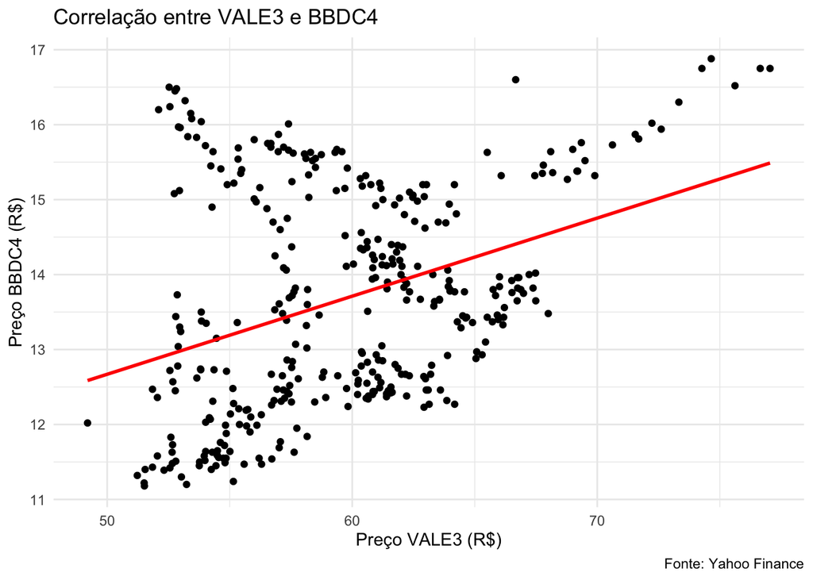

```r
# 4. Gráfico de dispersão com reta de regressão
ggplot(dados_largos, aes(x = vale, y = bradesco)) +
  geom_point() +
  geom_smooth(method = "lm", se = FALSE, color = "red") +
  labs(title = "Correlação entre VALE3 e BBDC4",
       x = "Preço VALE3 (R$)",
       y = "Preço BBDC4 (R$)",
       caption = "Fonte: Yahoo Finance") +
  theme_minimal()
```

**Interpretação**

5. Avalie se uma carteira formada por essas duas ações poderia ser considerada bem diversificada, com base na correlação estimada e na análise do gráfico de dispersão.

**Interpretação**

Do ponto de vista de diversificação de uma carteira de investimentos, essa correlação positiva **não** é uma característica desejável. Ao combinar ativos que se movem na mesma direção, o investidor não reduz o risco total da carteira, pois as perdas em um ativo não podem ser compensadas por ganhos no outro.

Portanto, com base na correlação positiva observada, essa carteira não seria considerada bem diversificada. Idealmente, uma boa diversificação exige a combinação de ativos com correlação próxima de zero ou negativa.